# Analysis of US Campaign donations by Pierre Hentges

> The dataset to be analysed is of campaign contributions to the US presidential elections from 2016. This includes donations in both the primary and general election campaigns, to candidates of all parties and across all US states. The dataset was downloaded from http://fec.gov and cleaned at the start, then saved as two .csv files (campaign2016data.csv, returned2016data.csv). Given the size of this data set -over 7 million records- most of the variables that will not be analysed have been removed. The cleaned data are submitted in the zip archive and are loaded in an early chunk of R code, while the two R chunks that clean the original file have been set to not run by default (“include=FALSE”).

# Univariate Plots Section

```
## [1] 7316484      10
```

The cleaned data set consists of 7.3 million contributions, with 10 variables. Let’s check them out more closely.

```
## 'data.frame':    7316484 obs. of  10 variables:
##  $ Candidate       : Factor w/ 25 levels "Bush, Jeb","Carson, Benjamin S.",..: 19 19 19 19 19 19 19 19 19 19 ...
##  $ Contributor_Name: chr  "OLSEN, GLENN" "OLSEN, GLENN" "JANELLI, REBECCA T." "ACCINELLI, THEODORA" ...
##  $ City            : Factor w/ 25106 levels "","-","???????????????",..: 1811 1811 580 580 580 580 580 16784 5956 580 ...
##  $ State           : Factor w/ 50 levels "AK","AL","AR",..: 1 1 1 1 1 1 1 1 1 1 ...
##  $ Contribution    : num  100 110 100 50 200 100 100 382 250 50 ...
##  $ Date            : Date, format: "16-02-16" "16-02-24" ...
##  $ Election_Type   : Factor w/ 2 levels "General","Primary": 2 2 2 2 2 2 2 2 2 2 ...
##  $ Party           : Factor w/ 5 levels "Democrats","Green",..: 5 5 5 5 5 5 5 5 5 5 ...
##  $ CandidateSurname: Factor w/ 25 levels "Bush","Carson",..: 19 19 19 19 19 19 19 19 19 19 ...
##  $ Occupation      : Factor w/ 37 levels "Academic","Admin",..: 29 29 29 18 18 13 13 NA NA NA ...
```

```
##                      Candidate       Contributor_Name
##  Clinton, Hillary Rodham  :3426975   Length:7316484
##  Sanders, Bernard         :2040636   Class :character
##  Trump, Donald J.         : 770038   Mode  :character
##  Cruz, Rafael Edward 'Ted': 556013
##  Carson, Benjamin S.      : 247294
##  Rubio, Marco             : 103656
##  (Other)                  : 171872
##             City             State          Contribution
##  NEW YORK     : 206789   CA     :1302012   Min.   : -93308
##  LOS ANGELES  : 102623   NY     : 648529   1st Qu.:     15
##  SAN FRANCISCO:  90829   TX     : 546776   Median :     28
##  BROOKLYN     :  87377   FL     : 424758   Mean   :    117
##  SEATTLE      :  82318   MA     : 295317   3rd Qu.:     87
##  (Other)      :6746545   WA     : 291843   Max.   :4904861
##  NA's         :      3   (Other):3807249
##       Date          Election_Type             Party
##  Min.   :13-10-01   General:2584914   Democrats  :5474694
##  1st Qu.:16-03-02   Primary:4731570   Green      :   8959
##  Median :16-05-27                     Independent:   1231
##  Mean   :16-05-19                     Libertarian:  13274
##  3rd Qu.:16-09-03                     Republicans:1818326
##  Max.   :16-12-31
##
##  CandidateSurname           Occupation
##  Clinton:3426975   Retired       :1647814
##  Sanders:2040636   Unemployed    : 644338
##  Trump  : 770038   Info Witheld  : 314460
##  Cruz   : 556013   Lawyer        : 240903
##  Carson : 247294   Senior manager: 230833
##  Rubio  : 103656   (Other)       :1802279
##  (Other): 171872   NA's          :2435857
```

- many of the variables are categorical (or factorised), including the 25 presidential candidates and their party, whether the contribution was made in the primaries or general election, information on the contributor (state, occupation)
- the only numeric variable is Contribution amount, and the date of the contribution. These will be studied first.
- the majority of contributions (4.7 million) were in the primaries, 2.6 million for general election
- Clinton and Sanders got a lot more contributions than Trump, also the Democrats got far more contributions than the Republicans
- a number of variables (contributor name,address,employer,receipt comments etc) have been dropped as they won’t be analysed.

I’ll start by looking more closely at the Contributions variable. The Contributions variable has a surprising range: from negative (-$93308) to $4.904.861.

I’ll disregard the negative contributions for now and look at the distribtion of positive contributions. The negative contributions have been split off in a separate dataframe, to be analysed further down. This dataframe which has additional columns that have been dropped from the main dataframe for memory efficiency reasons.

```
##    Min. 1st Qu.  Median    Mean 3rd Qu.    Max.
##       0      15      28     124      97 4904861
```

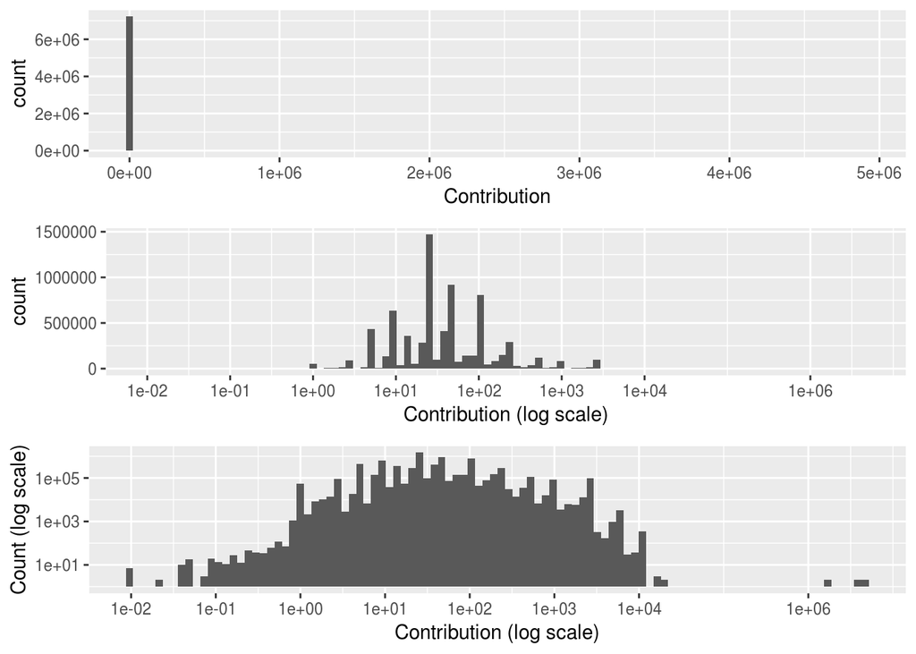

The campaign contribution data are extremely right-skewed: in a histogram with 100 bins, 7 million donations are grouped in a single bar. Using a logarithmic x scale: much of the data are now visible over 2 orders of magnitude, but extreme values are still not discernible. Using logarithmic scales for both the x and y axes makes outliers visible. The shape now approximates a symmetric distribution more. The donations of several million $ are clearly outliers as they are 2 orders of magnitude away from the rest of the data. One could argue that the small number of donations below $0.10 could also be classified as outliers since they are separated from the rest of the data.

To better understand the values at the very top and bottom percentiles I will look more closely at these outliers.

```
##      0.01%       0.1%        95%        99%      99.9%     99.99%
##       0.80       1.00     400.00    2700.00    2700.00    5400.00
##    99.999%   99.9999%       100%
##   10800.00   74135.61 4904860.51
```

It is noticeable how the top quantiles of 99.9% and 99.99% well below $10K. Looking at quantiles, 0.1% to 99.9% corresponds to $1 - $2700 ; and 0.01% to 99.99% corresponds to $0.80 - $5400. These may be related to campaign finance legal limitations.

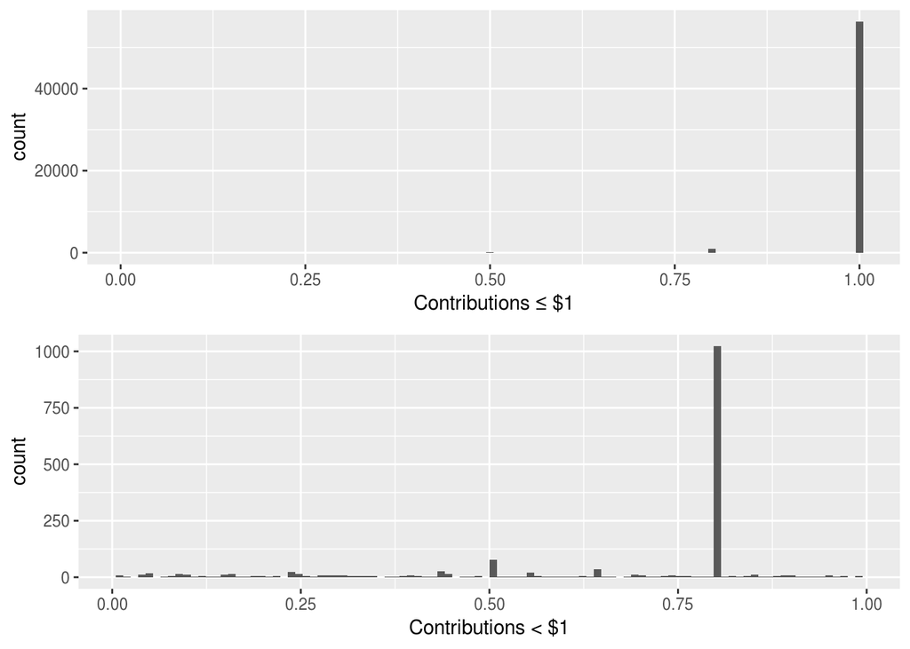

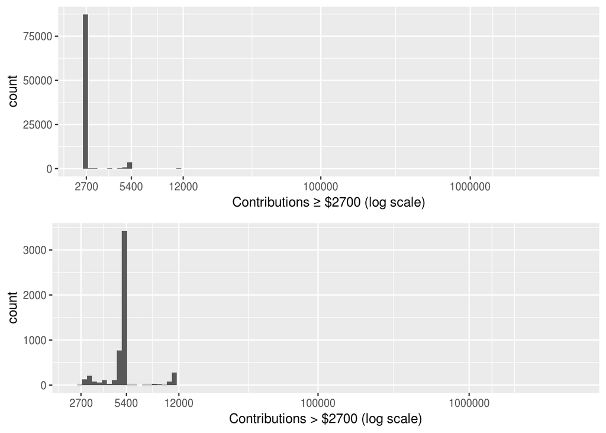

```
##                       Candidate                  Contributor_Name
## 3205926 Clinton, Hillary Rodham HILLARY VICTORY FUND - UNITEMIZED
## 3250729 Clinton, Hillary Rodham HILLARY VICTORY FUND - UNITEMIZED
## 3253844 Clinton, Hillary Rodham HILLARY VICTORY FUND - UNITEMIZED
## 3256657 Clinton, Hillary Rodham HILLARY VICTORY FUND - UNITEMIZED
## 3286398 Clinton, Hillary Rodham HILLARY VICTORY FUND - UNITEMIZED
## 3291093 Clinton, Hillary Rodham HILLARY VICTORY FUND - UNITEMIZED
## 3301177 Clinton, Hillary Rodham HILLARY VICTORY FUND - UNITEMIZED
## 6827396        Trump, Donald J.                       BOCH, ERNIE
## 7293177         Kasich, John R.               B&J DEVELOPMENT LLC
## 7293179         Kasich, John R.        NAP INVESTORS HOLDINGS LLC
##         Contribution     Date Election_Type
## 3205926    4904860.5 16-03-31       Primary
## 3250729    1797624.9 15-12-31       Primary
## 3253844    1603724.4 15-12-04       Primary
## 3256657    1467070.9 16-01-31       Primary
## 3286398    3686373.3 16-02-29       Primary
## 3291093    3600489.1 16-04-29       Primary
## 3301177    4575438.6 16-05-31       Primary
## 6827396      86936.8 15-08-28       Primary
## 7293177      25000.0 15-12-30       Primary
## 7293179      29100.0 15-12-30       Primary
```

There are 10 contributions above $20,000, all occurred in the primaries campaign. 7 of these are from the “Hillary Victory Fund” and amount to several million dollars each - these are clearly outliers. The remaining contributions above $20,000 are in the 5 figure region, one to Trump and two to Kasich, both occurring long before the primaries started.

Let’s look at the impact of the outliers on the mean:

```
## Summary statistics of (all positive) donations :
```

```
##    Min. 1st Qu.  Median    Mean 3rd Qu.    Max.
##       0      15      28     124      97 4904861
```

```
## Summary statistics after removing Contributions > $1 million  :
```

```
##     Min.  1st Qu.   Median     Mean  3rd Qu.     Max.
##     0.01    15.00    28.00   121.23    96.59 86936.80
```

Removing outliers above $1 million reduces the mean from $124 to $121 - this is still far higher than the median of $28.

```
## Summary statistics after removing the top and bottom 0.01% of contributions:
```

```
##    Min. 1st Qu.  Median    Mean 3rd Qu.    Max.
##     1.0    15.0    28.0   117.2    95.0  2700.0
```

Removing the top and bottom 0.01% quantile reduces the mean further to $117.2 - still far higher than the median of $28. These observations imply that, although the outliers of contributions above $1 million do significantly raise the mean contribution, the distribution of the rest of the contributions is still strongly right-skewed. In fact, the strength of the right-skewness is consistent with the notion that the contributions are log-normally distributed. To look into the issue of whether the bulk of contributions (those between $1 and $2,700) is log-normally distributed, I will look at their distribution further using histograms with a log axis for the amount contributed:

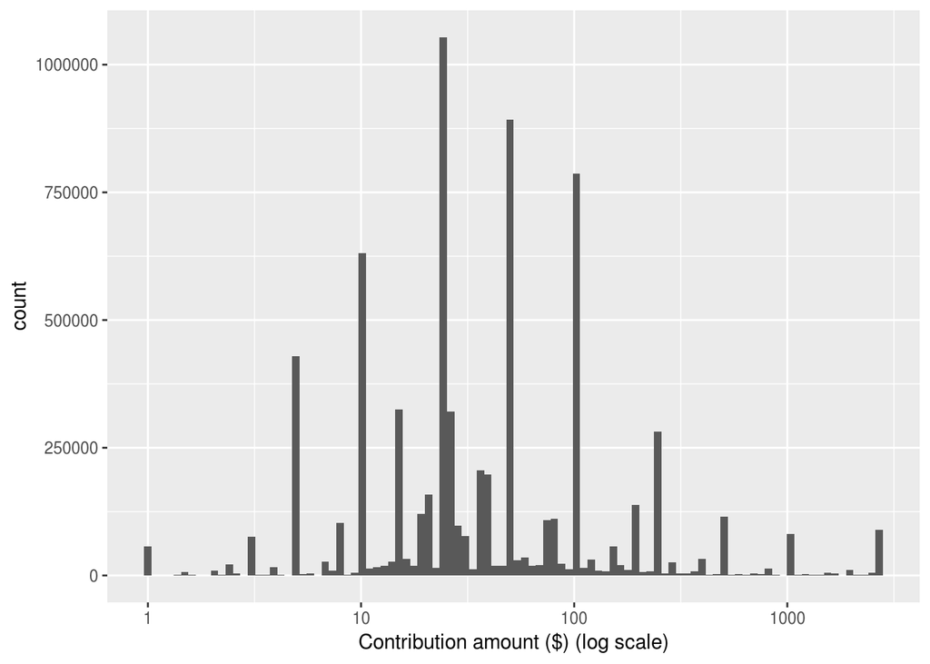

Looking at the bulk of contributions between $1 and $2,700 shows the discreteness of the donations variable - this is because contributors don’t arbitrarily choose real numbers but rounded amounts such as $10, $20 or $100 are far more common. However, the peaks of the common contributions appears to follow a approximately normal distribution in the plot above. The same can be said for bars representing less common amounts. This discreteness can distract from the overall shape of the distribution. For that reason I’ll study the shape of the distribution further by reducing the number of bars in the histogram from 100 to 8 :

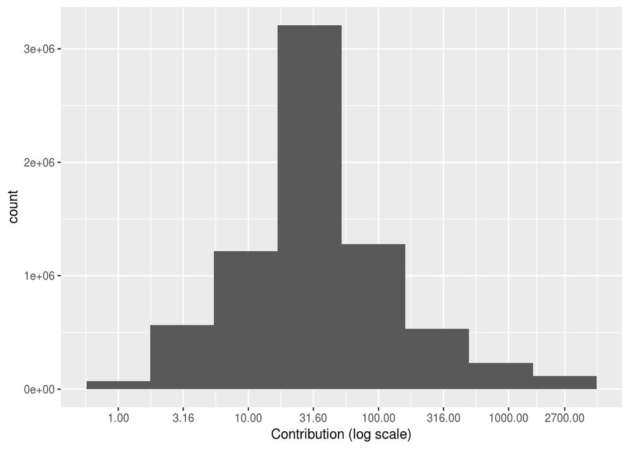

When donations between $1 and $2,700 are represented by a histogram with 8 bins and a logarithmic axis for the amount contributed, their distribution comes close to a normal distribution - although they are still slightly right-skewed.

In what follows, plots involving the variable of the amount contributed will often use a logairthmic axis when the approximately log-normal distribution matters.

This distribution relates to the *number* of contributions - but how about the total sums raised? Small contributions are important but the total sums raised are more important from the point of view of election candidates that need to run an expensive campaign. To answer this question, I want to compare the 8 bins in the histogram above to the total raised in each of them.

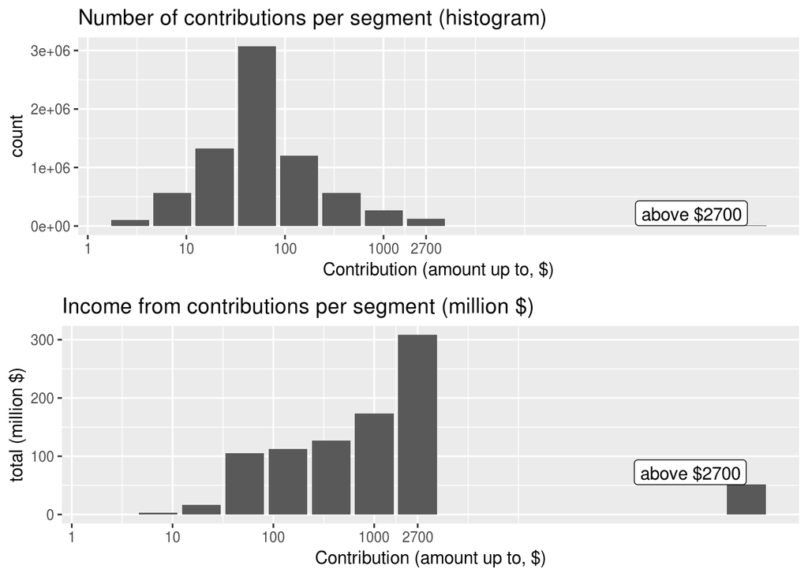

In the two plots above, contributions are grouped into 8 bins by amount contributed between $1 and $2,700, plus a 9th bar for all contributions above $2700 (including outliers). The bin boundaries defining the 8 segments are set to fit on a logarithmic axis. The top plot displays the number of contributions in each segment - effectively a histogram for the first 8 segments - while the bottom plot displays the total income campaigns receive from each of the segments (the sum of the contributed amounts in each segment). (The actual figures represented in the two plots are shown in the table below.)

Thus, while most common contributions are in the fourth segment (over 3 million contributions from $19.4 to $52, with a median of $27), raising only just above $100 million, a much larger source of campaign income -over $300million- is represented by around 125,000 contributions in the 8th segment of $1005 to $2,700 (median of $,2700). Noteworthy also that the group of donations above $2700, with a median of $5400, is the source of $51 million, (i.e. around half of the 3 million contributions in the 4 segment) even though it comes from only 5390 contributions.

The two plots highlight the importance of distinguishing between the distribution of the number of contributions and the amounts raised - which are a reflection of the aproximately log-normal distrubtion of contributions.

```
## # A tibble: 9 x 5
##   cuts                 count upper_bound        sum median
##   <fct>                <int>       <dbl>      <dbl>  <dbl>
## 1 [1,2.68]            100740        2.68    148886.      1
## 2 (2.68,7.21]         565780        7.2    2707353.      5
## 3 (7.21,19.4]        1321186       19.4   16228090.     10
## 4 (19.4,52]          3070772       52.0  105421504.     27
## 5 (52,140]           1202017      140.   112072946.    100
## 6 (140,375]           566342      374.   127367646.    250
## 7 (375,1.01e+03]      262382     1005    173604870.    500
## 8 (1.01e+03,2.7e+03]  125105     2700    308295215.   2700
## 9 <NA>                  5390  4904861.    51213475.   5400
```

Let’s come back to the negative contribution values - who donates negative money to a campaign??

```
## [1] 94927    14
```

```
##      Min.   1st Qu.    Median      Mean   3rd Qu.      Max.
## -93308.00   -275.00    -80.00   -466.86    -27.00     -0.01
```

There are around 95 thousand ‘negative contributions’. The median and the mean are (in absolutely value) larger than the median an the mean of positive donations studied above.

For comparison with the previous insights on distribution, I’ll look at the distribution of contributions in the $1 - $2,700 range (using log axis, and showing absolute values by multiplying by -1).

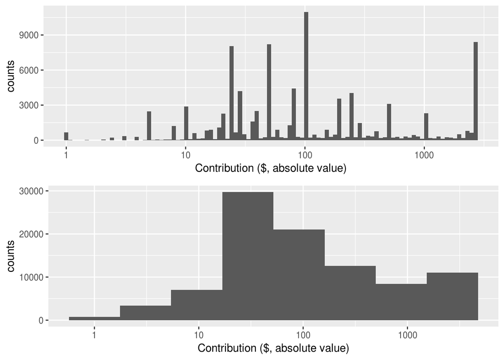

Negative contributions are skewed towards higher amounts, especially those close to $2,700.

The original data contain a column for receipt descriptions. What are the most common values of this variable?

```
##
##                                Refund
##                                 50370
##
##                                 25028
##              REDESIGNATION TO GENERAL
##                                 10142
##               REATTRIBUTION TO SPOUSE
##                                  4495
##      REDESIGNATION TO CRUZ FOR SENATE
##                                  4426
## REDESIGNATION TO PRESIDENTIAL GENERAL
##                                   246
```

“Negative” campaign contributions are typically contributions refunded to donors, contributions redesignated to the another election (e.g. general), or reattributed to the donor’s spouse.

Let’s look at the 5 number summary for those marked “Reattribution to spouse”, “Refund”, and “redesignation to general” :

```
## REATTRIBUTION TO SPOUSE  :
```

```
##    Min. 1st Qu.  Median    Mean 3rd Qu.    Max.
## -5400.0 -2300.0  -250.0  -976.4   -50.0    -1.0
```

```
## Refund  :
```

```
##      Min.   1st Qu.    Median      Mean   3rd Qu.      Max.
## -93308.00   -270.00   -100.00   -423.65    -25.00     -0.01
```

```
## REDESIGNATION TO GENERAL  :
```

```
##    Min. 1st Qu.  Median    Mean 3rd Qu.    Max.
## -2900.0 -2300.0  -250.0  -929.1   -50.0    -0.2
```

The median and interquartile range are really rather different from the corresponding values for positive donations!

Are these returned donations used equally by all candidates?

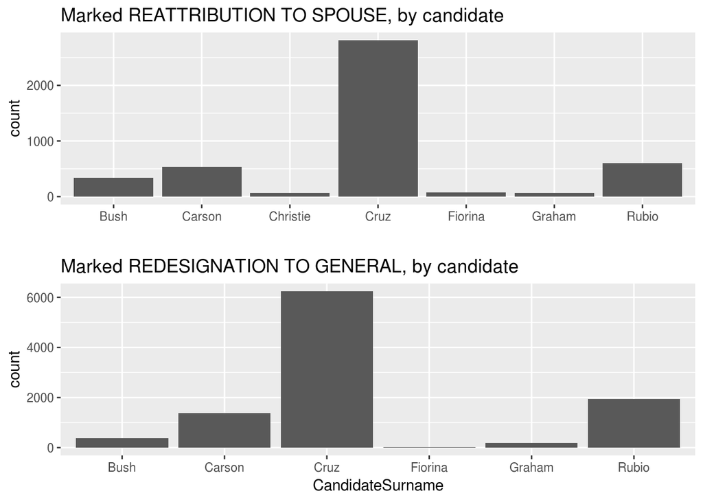

Some categories of donations are used only by a few top republican candidates, in particular Cruz.

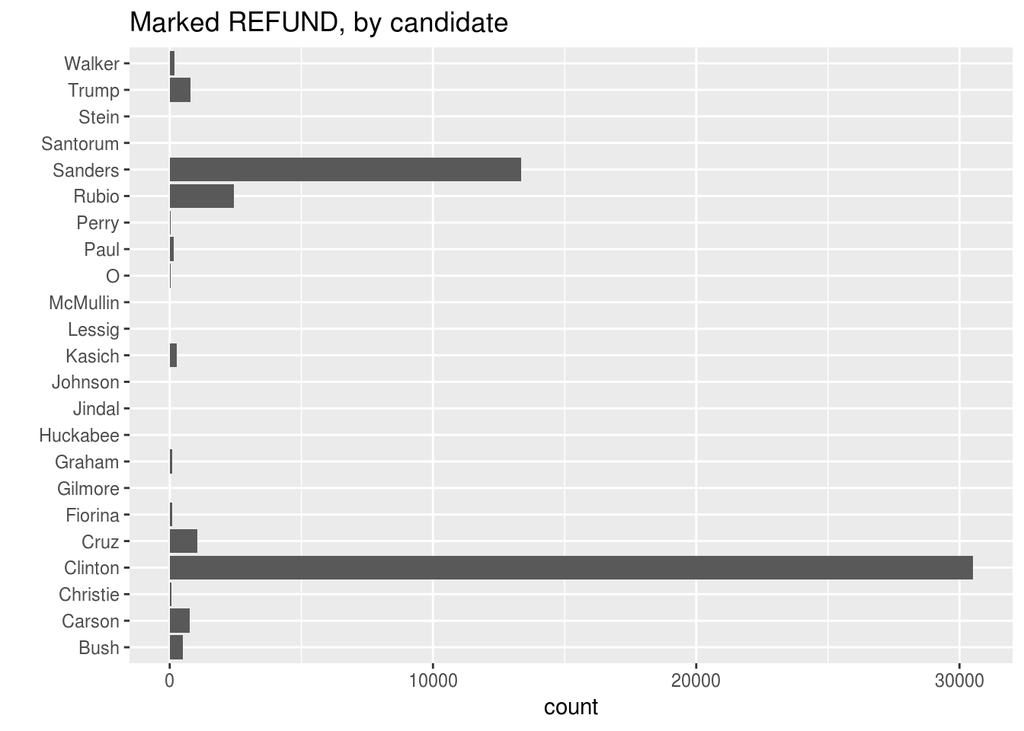

The Refund category is mainly used by the two top Democratic candidates Clinton and Sanders.

```
##                     Candidate  Contributor_Name receipt_desc memo_cd
## 7410      Carson, Benjamin S.         REID, SUE       Refund
## 7411      Carson, Benjamin S.         REID, SUE       Refund
## 35875 Clinton, Hillary Rodham GOCKE, THOMAS DR.       Refund
## 69090        Sanders, Bernard      CARANGI, JOE       Refund
## 78134        Trump, Donald J.      HYDE, ROBERT       Refund
##             memo_text
## 7410
## 7411  REFUND REISSUED
## 35875
## 69090
## 78134
```

There are 5 refunded contributions above $15,000.

The shape of negative contributions differs from positive contributions, i.e. median and quartiles are much higher.

“Negative” contributions represent money returned to the donor either as a refund, or part of being reassigned to a different purpose. While these may not seem very interesting, they are commonly the outcome of donors exceeding campaign limitations. However, negative values are removed from the main dataset and will not studied further.

There are a lot of other variables in the data set which I will be looking at to gain a better understanding of the data set. Many are categorical, so often this is about looking at counts. First, let’s look at election type and party.

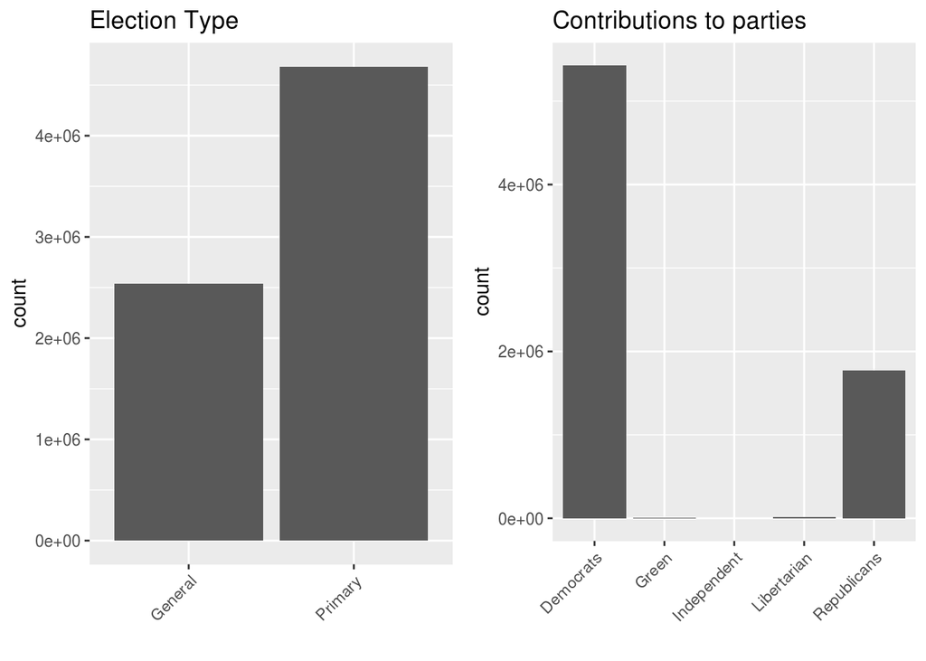

The majority of contributions were made in the primaries, and only about a third of were made in the general election.

The Democratic party received by far the largest number of contributions - over twice as many as the Republican party. Contributions to third party candidates are barely noticeable.

While most of the remaining variables are categorical, the date of contributions can be usefully studied using histograms.

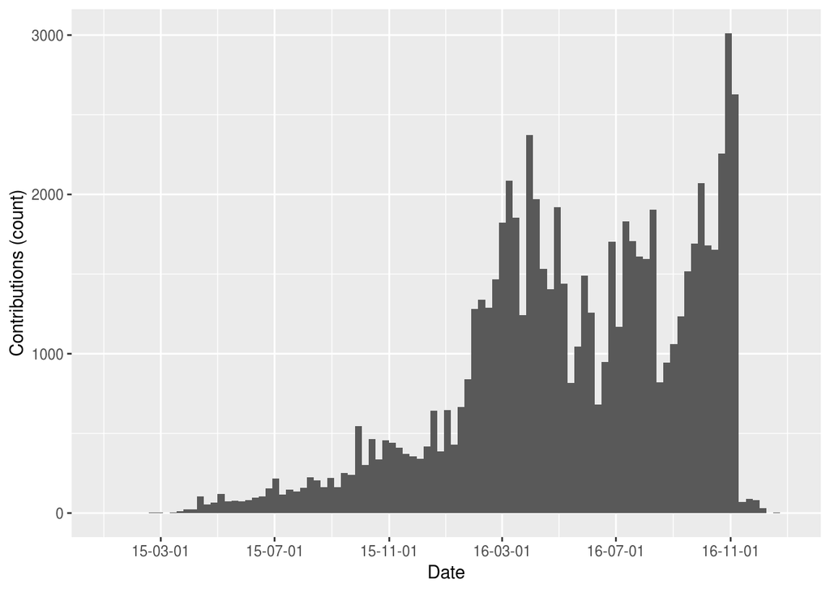

The histogram of when contributions were made shows a slow rise til early 2016 - around February - when contributions reach a much higher level. A peak is reached in the week of the election (8. November 2016.). Does this pattern correspond to primaries/general election?

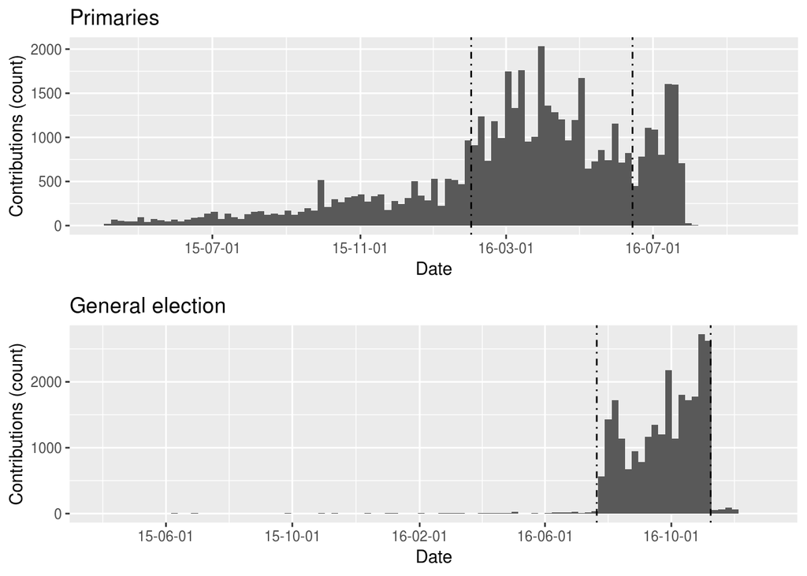

Vertical lines indicate the start/end of primaries (top) as well as the Republican convention (start of general election) and election day (bottom). Contributions for the general election only really get going once the primaries are over.

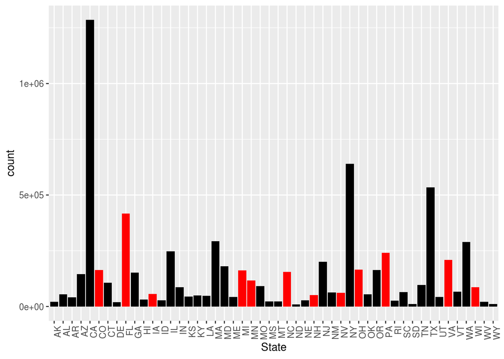

The histogram shows the number of donations per state, swing states are in red. The number of contributions is elevated in California, New York and Texas. This probably reflects the relative population size.

How about the different candidates? Bar charts of donations grouped by party affiliation. First Republican candidates.

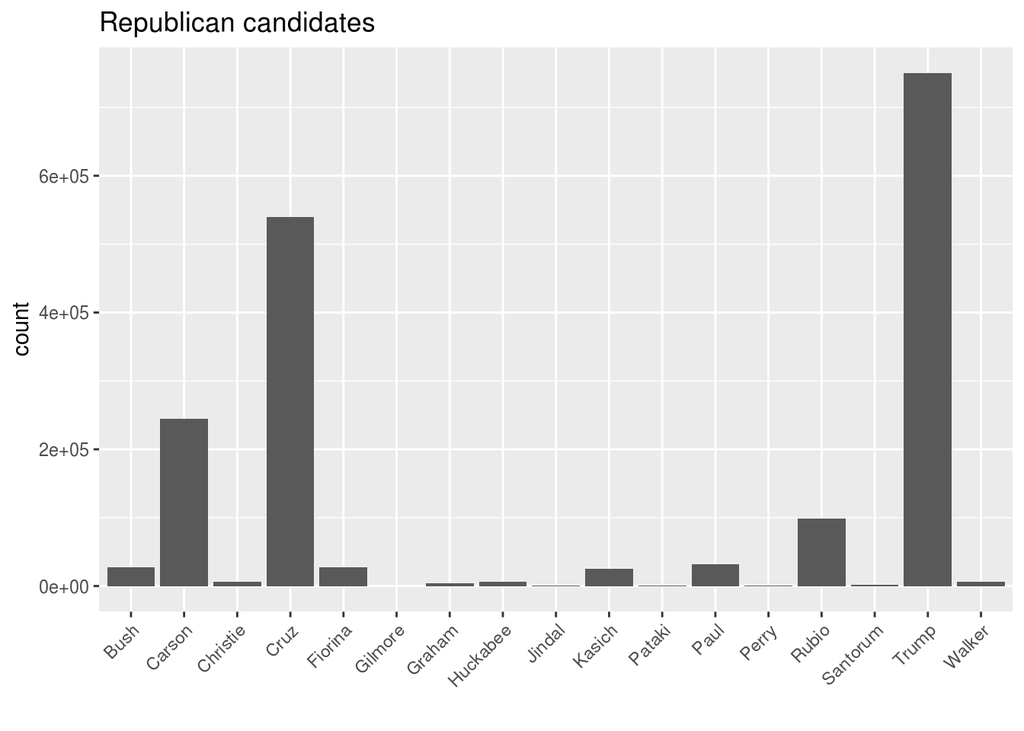

There are a lot of Republican candidates, and the number of donations to them varies enormously. Some get a lot fewer donations to the extent that they could be ignored for analysis, but there is no obvious cut-off that could be used to distinguish between the ‘main’ vs ‘marginal’ candidates.

Next Democratic Party candidates, and, in one chart, third part candidates, i.e. Greens, Libertarians, Independents.

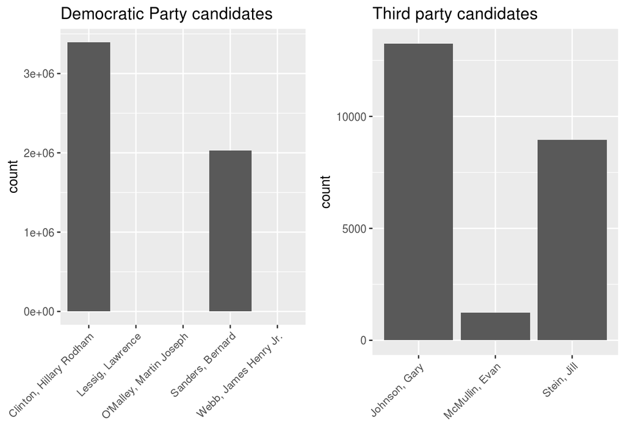

As for third part candidates, the number of contributions they receive is not in the same league as the two main parties. For the remainder, analysis will focus on candidates from the two main parties.

Finally, data is available for the contributor occupation. However, plaintext entry means that this is very inconsistent and had to be extensively cleaned. However, only the 36 most common occupation categories were used, plus “Info Witheld” category. Some of the categories, such as “Retired”, “Homemaker” or “Disabled” are not jobs, but define demographics whose political participation is interesting to study as a group. For the remainder, this variable will contain NA:

```
##          Academic             Admin         Architect              Arts
##            154502             58637             17204            112552
##    Business owner      Construction        Consultant        Contractor
##             80351              7093             80417             10480
##          Disabled            Doctor            Driver       Electrician
##             15612            165225              7646              7619
##          Engineer            Farmer           Finance         Homemaker
##             78704             17362            105565            108264
##      Info Witheld            Lawyer         Librarian          Mechanic
##            263465            239879             13789              3726
##             Media             Nurse            Pastor        Pharmacist
##             36862            100781              5390             12400
##             Pilot     Programmer&IT      Psychologist       Real Estate
##              8725             85715             39195             48973
##           Retired Sales & marketing     Self-employed    Senior manager
##           1629570             95088             61698            228385
##     Social Worker           Student           Teacher      Truck driver
##             22637             47130            171732             11275
##        Unemployed              NA's
##            643975           2423711
```

While data cleaning categorised a large majority of donors, for 2.4 million contributions, the descriptions were too low-quality to easily categorise. Let’s compare the contributions for which there if occupation information:

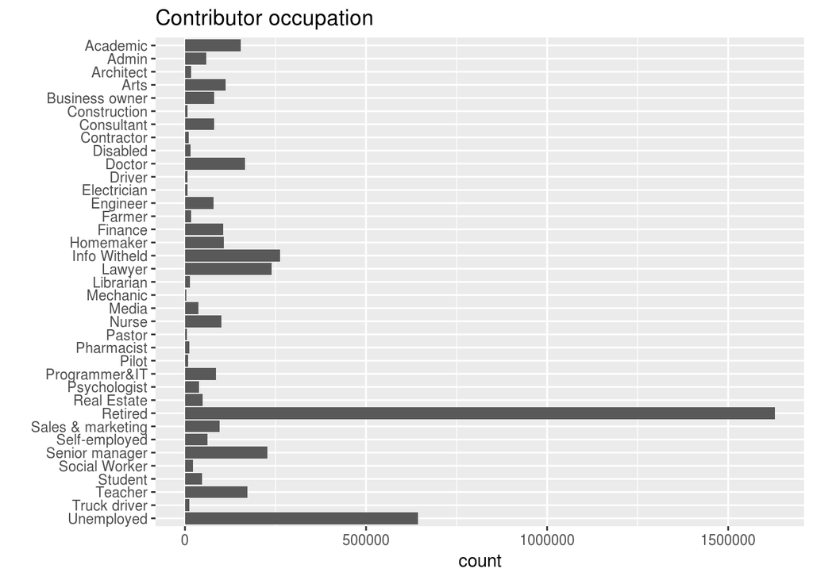

Contribution occupation is dominated by Retired people, as well as the unemployed. To some extent, this is because these category are much wider than particular job categories. More specific job categories are dominated by white collar jobs, such as lawyers, academics, doctors. Contributions with occupation “Info withheld” also stand out.

# Univariate Analysis

### What is the structure of your dataset?

In order to drop variables relating to campaign receipt information, negative contributions have been split off into a small separate dataframe (returned2016) which still contains these variables, and which is analysed briefly early on.

### What is/are the main feature(s) of interest in your dataset?

The campaign contribution amount is the key feature, as it expresses a donor’s political support and an attempt to influence the election outcome. To interpret this, one needs to study this variable’s relationship to other key variables, such as which candidate/party the contribution went to, who made the contributions, when they were made in the campaign (primary/general, early/late).

### What other features in the dataset do you think will help support your investigation into your feature(s) of interest?

The key feature, the individual election contribution, could be thought of as an individual vector whose size and direction is an expression of political support. To properly investigate this key feature, one needs to look at the origin (donor) and target of the vector (candidate/party). One can also consider these vectors as being additive in terms of demographics - aggregating the contributions of donors sharing by occupation or geographical location can be interpreted as an expression of collective political will.

An election campaign is a dynamic process that unfolds over time, and which is shaped by external events as well as, for example, some candidates exiting the race, the time when contributions were made is important to make sense of what is happening.

Candidate party affiliation and election type (primaries/general) are also crucial, as during the primaires stage, we’re effectively looking at two separate races occuring in parallel, before the main “two-horse race” of the general election campaign.

Another feature supporting the investigation is occupation: this enables us to get an understanding of the different candidates’ social base.

There are further features that would be interesting to take into consideration- in particular, the donor’s employer, and their geographical location (ZIP). These could be used to study the effect of wider economic intrests, as well as demographic effects (urban vs rural, areas of deprivation, etc) using additional socio-economic data. However, the work required is beyond the scope of the present study.

### Did you create any new variables from existing variables in the dataset?

Yes: the candidates’ party affiliation was not originally available, and needed to be created as a variable.

The very low-quality occupation data was used to create a new variable with 37 different categories.

Also, Candidate surname was created as the full-name often takes up too much space in axis labels.

### Of the features you investigated, were there any unusual distributions?

Yes - intersting features of the contribution amount are the outliers, the log-normal distribution, and the negative contributions.

The extreme outliers of contributions amounting to several million dollars to the Clinton campaign in fact come from the Hillary Victory Fund. These outliers - well beyond the normal contribution limitations - in fact represent an aggregation of much smaller donations. However this joint fund was controversial, with Sander’s alleging it aimed to “skirt fundraising limits on [Clinton’s] presidential campaign”. (source: https://en.wikipedia.org/wiki/Hillary_Victory_Fund)

Looking at quantiles, the 99.9 percentile is $2700 ; while the 99.99 percentile is $5400. Interestingly these values correspond to legal limits on contributions (donations limit for individuals and married couples, respectively) and thus reflect how regulatory measures shape how campaign finance works. (source: https://transition.fec.gov/pages/brochures/citizens.shtml)

After removing outliers, and restricting the analysis to contributions ranging from $1 to $2700, it became clear that its distribution approximates a log-normal distribution (though this is still slightly right-skewed). This distribution probably reflects the wealth distribution in US society - which is also log-normal.

Finally, there are negative contributions whose distribution varies from the rest of contributions. These contributions are often associated with campaign finance limits. A common approach when a donation exceeds the legal individual limit of $2,700 is to re-attribute the excess to a donor’s spouse - which is then registered as a negative contribution.

### Did you perform any operations on the data to tidy, adjust, or change the form of the data? If so, why did you do this?

Yes, the low-quality occupation data was reduced and factorised to 37 different categories - though over 2 million contributions resisted this data cleaning measure. This data cleaning measure simultaneously made data analysis possible as well as reducing the memory footprint of this variable.

Also, a number of records were dropped - those not relating to either the primaries or general elections. “Negative donations” were split off into a separate dataframe in which variables only relevant to the analysis of negative donations were preserved.

# Bivariate Plots Section

The variables investigated in this section : * date vs election type variables: comparison of the primaries and general election over time * candidate vs contribution amount variables: comparison of candidates of the same party according to the contribution amount. Since only a single candidate per party remains in the general election, the data are restricted to donations in the primaries * candidate vs date variables : comparison of condidates in terms of when they received donations * party/candidate vs contribution amount: relative aggregated ontributions and preference for one candidate over another

To compare primaries and general election over the contribution date, a frequency polgon is a good way of comparing these, and using log y-axis given the log-normal distribution of contributed amounts.

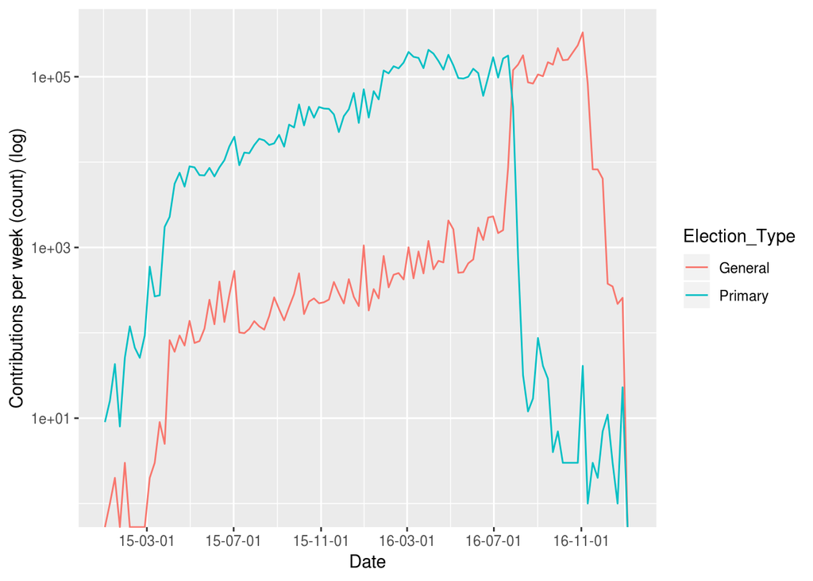

The (total) number of contributions per week continues to rise over the course of the campaign. However there is a clear cross-over point when the primaries finish. Interestingly, general election contributions do occur during the primaries, and primaries contributions are recorded during the general election campaign - the latter may be candidates that are no longer in the race but still need to pay off expenses. During the primaries, primaries contributions are around 2 orders of magnitude (100fold) larger than those for the general election until the cross-over point in August 2016.

What about the total amounts contributed during the primaries and general election campaigns?

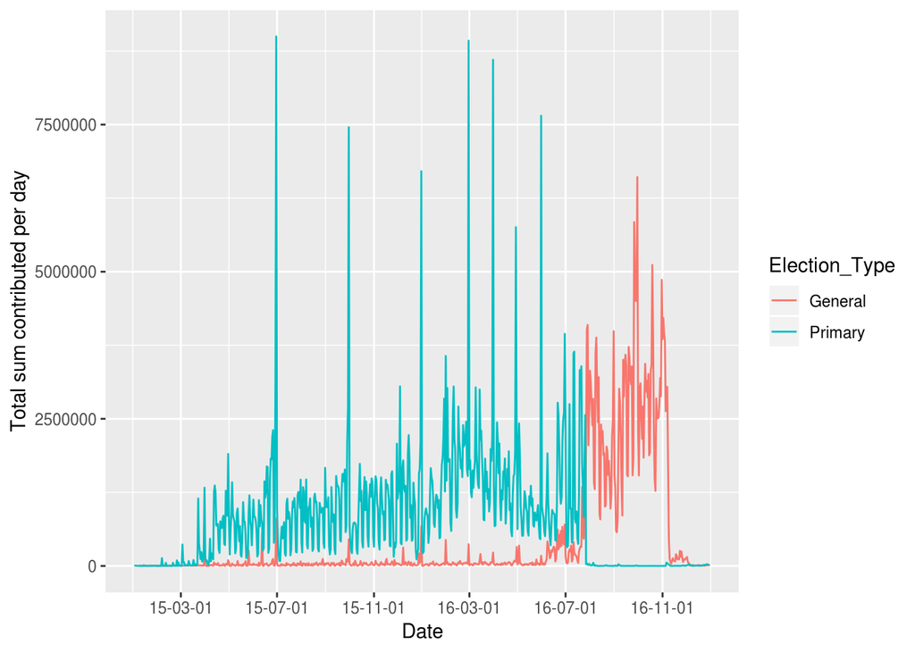

The sum of daily contributions follows a similar pattern as the number of contributions in that there is a clear cross-over point in August 2016. However, the timeline for the sum of contirbutions is noisier as it is daily rather than the weekly number of contributions shown in the previous plot. The total amounts are likely also influenced by the time points at which specific candidates leave the race. The visible spikes are due to the outliers identified in the earlier section.

Now for a closer look at the primaries and what happens between candidates. During the primaries, the race is between multiple candidates of the same parties, unlike in the general election, when it is between different parties. I will starting by looking at the Democrats.

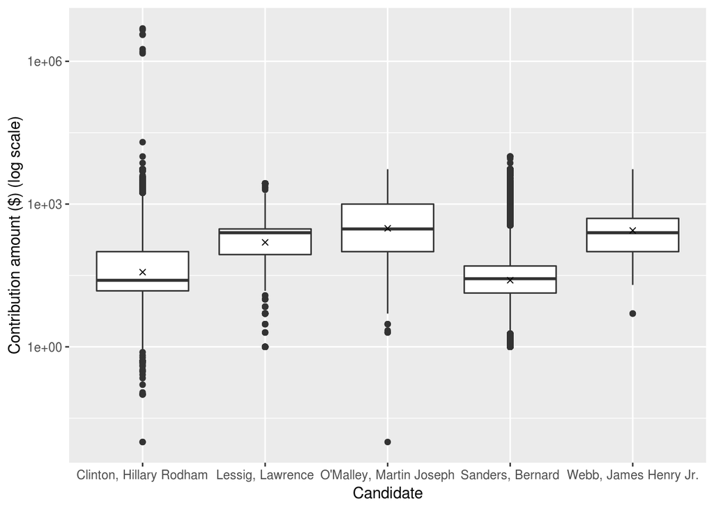

The mean contribution for each candidate is indicated by a cross. There are quite substantial differences in the average donations for different candidates, with Sanders and Clinton significantly lower median contributions than the other democratic candidates. There are quite prominent outliers for Clinton of several million dollars - these are the outliers previously discussed. For Clinton, the mean contribution (cross) is higher than the median - this is due to these outliers. In comparison, for Lessig, the mean is lower than the mean, due to a number of outliers at the low end.

To look more closely at the mean and five number summaryfor the two main Democratic party candidates, here are the summary stats:

Clinton summary statistics:

```
##    Min. 1st Qu.  Median    Mean 3rd Qu.    Max.
##       0      15      25     180     100 4904861
```

Sanders summary statistics:

```
##     Min.  1st Qu.   Median     Mean  3rd Qu.     Max.
##     1.00    13.50    27.00    47.49    50.00 10000.00
```

At $180, the mean contribution in the primaries for Clinton is much higher than for Sanders ($47.49). Is this entirely due to the outliers? Here are the summary statistics for Clinton, with outliers removed by only considering contributions up to $10.000 (the maximum for Sanders):

```
##    Min. 1st Qu.  Median    Mean 3rd Qu.    Max.
##    0.01   15.00   25.00  162.41  100.00 7300.00
```

Removing the outliers lowers the mean contribution for Clinton in the primaries to $162.41 - but this is still much higher than for Sanders, even though the median amount contributed is relatively similar ($25 for Clinton, $27 for Sanders). This means that, while the distribution of contributions is right-skewed for both candidates, it is far more skewed for Clinton, and on the basis of these numbers, the expectation is that a higher proportion of contributions received by Clinton fall in the higher categories.

To compare the distribution of contributed amounts between Clinton and Sanders, we can plot a histogram of the contribution amounts (to compare the dstributions for the two candidates, the amounts are normalised by calculating the density, and only contributions between $1 and $10.000 are considered):

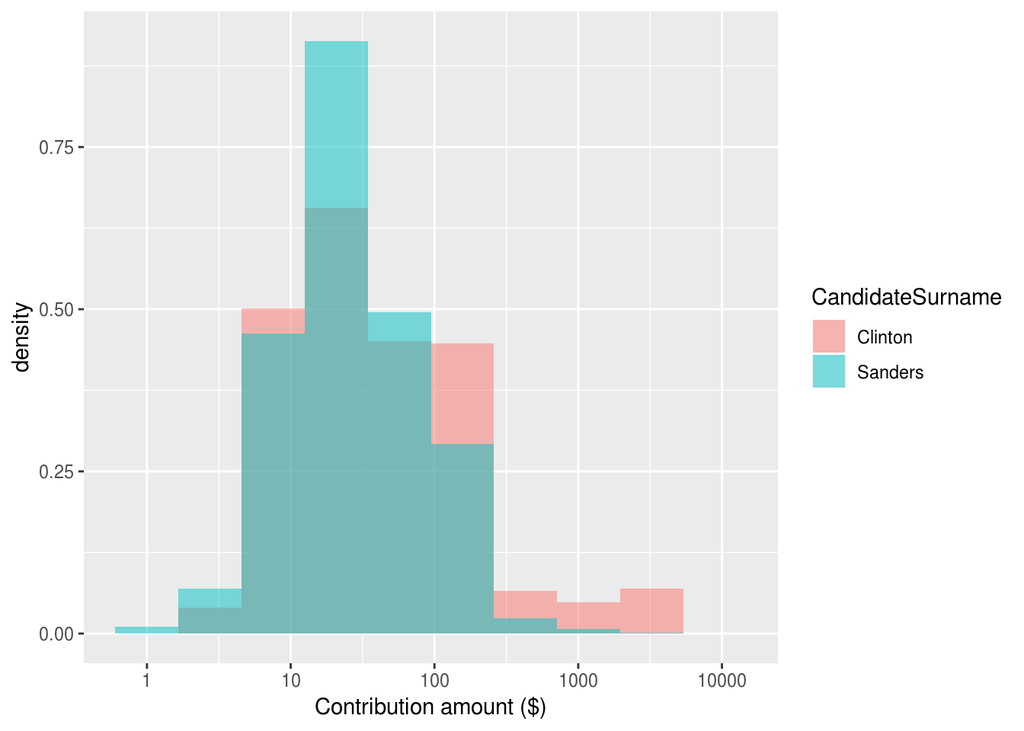

Amounts are plotted on a log-axis and 10 bins are used. Looking at these “log-transformed deciles”, a higher proportion of the contributions to the Sanders campaign fall in the 4th and 5th “log-decile”, while the Clinton primary campaign receives a higher proportion of contributions in the 6., 7., 8., 9. “log-decile”.

When did Democratic party candidates receive the most donations? We can look at this using a frequency polygon of the number of donations received each week. The vertical line marks the first primary contest on February 1, 2016. While Lessig and Webb had suspended their campaigns before the start of the first primary, O’Malley withdrew following 1. February, after which Clinton and Sanders were the only 2 candidates left in the contest. The second vertical line marks the final primary in the District of Columbia on June 14. (source: https://en.wikipedia.org/wiki/2016_Democratic_Party_presidential_primaries)

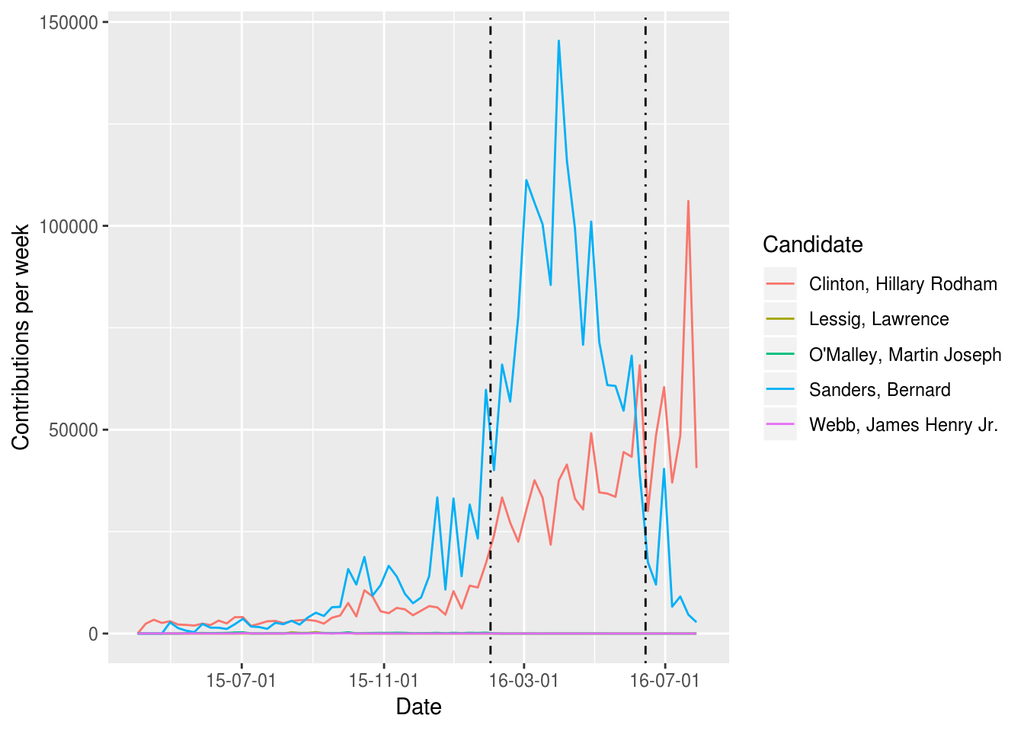

Using a linear rather than a log axis, the contributions for any candidates other than Clinton and Sanders are unnoticeable.

While Sanders’ contributions peaked in the middle of the primaries - perhaps as a result of enthusiasm for Sanders ebbing as his chances of winning the primaires waned, Clinton campaign contributions continued to rise as the general election approached.

How does this relate to the total amount of contributions received?

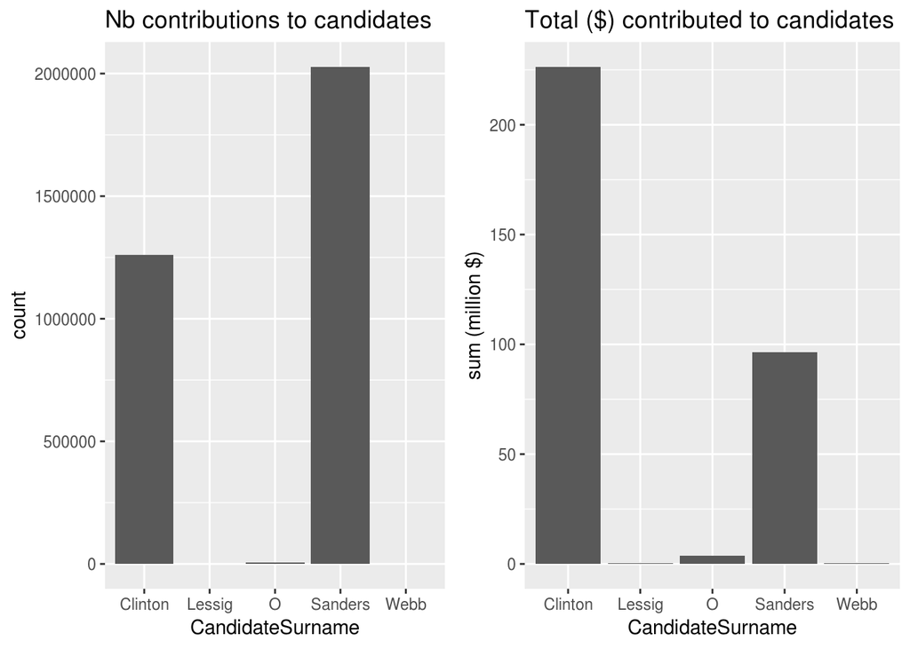

Two things stand out here: (1) candidates other than Clinton and Sanders are almost invisible ; (2) while Sanders receives far more contributions than Clinton, Clinton receives more than twice as much money. In part this is due to the fact that the “Hilary Clinton Victory fund” aggregates numerous smaller donations. However, as point out above, even if we exclude these, Clinton’s campaign contributions are much more right-skewed as she receives more large donations than Sanders.

Let’s look at a new variable: donor occupation. Who are the people donating money to the two main Democratic party candidates? Which are the top 5 categories for each candidate? (totals in million dollars)

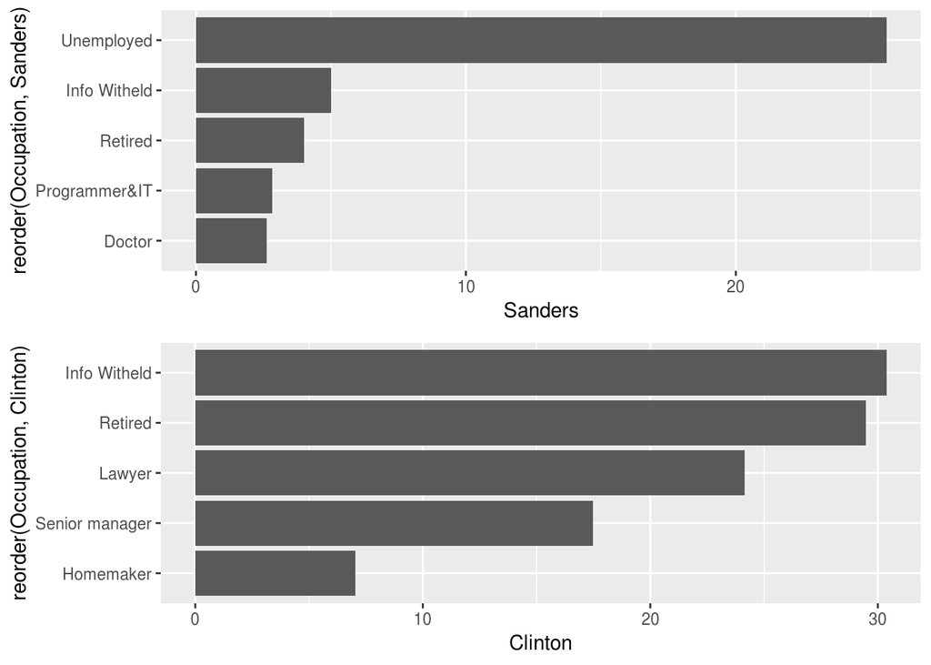

The difference betwen the two candidates is striking. While Retired people and those who withold occupation info are to be expected to be in the top 5 because they are the largest catgories overall, Sanders receives far more money from unemployed people.

To some extent, this ranking will be determined by how occupation categories were defined during the data cleaning step. To make this more meaningful as a comparison between the support base of the two candidates, I want to look at the number of contributions (to remove the effect of some demographics having much higher disposable income) and at the imbalance in which candidate is most preferred by donors of the same occupation.

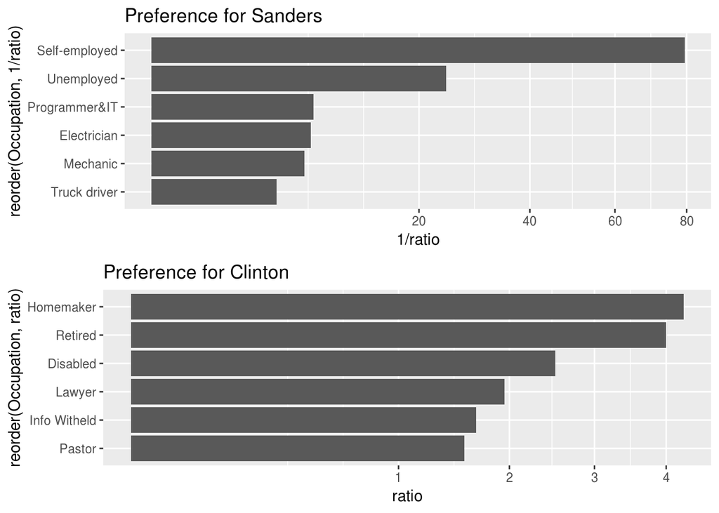

Self-employed donors are 80 times more likely to contribute money to Sanders than to Clinton. Unemployed donors are over 20 times more likely to contribute money to Sanders. Sanders is also much preferred by donors in someblue-collor occupations - eletcricians, mechanics, truck drivers.

By comparison, those occupations which favour Clinton over Sanders only express a milder bias of maximum 4 times.

Next for a similar analysis of Republican primaries.

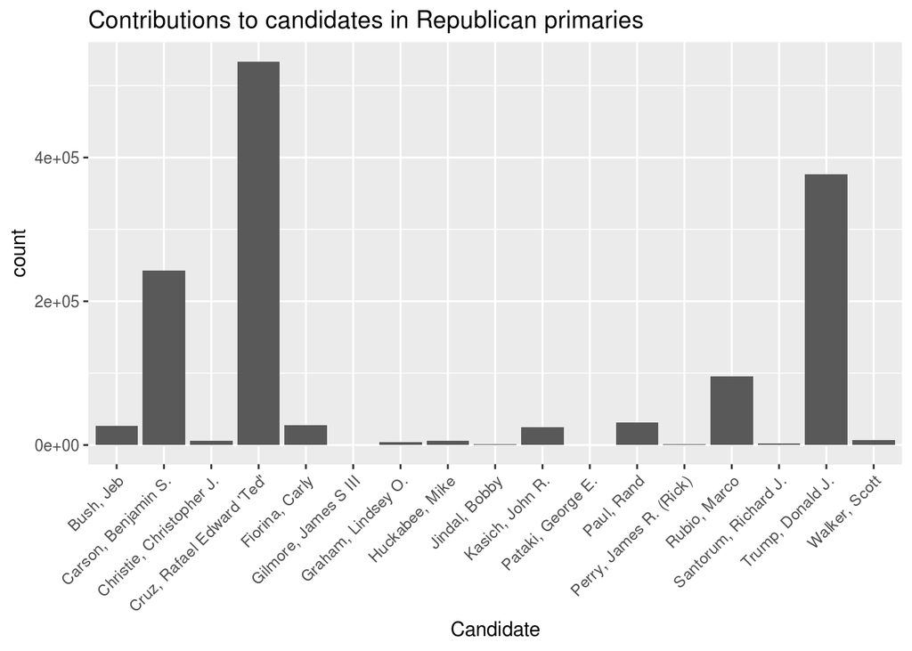

There were 17 candidates from the Republican party. As it can be difficult to visualise this many candidates in a plot, I will focus more on the final 5 which remained in the race. What are the total amounts received by each candidate’s campaign?

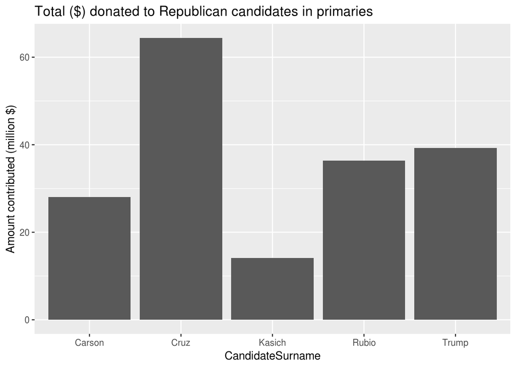

Contributions to the primary campaign of Cruz was significantly larger than Trump, Rubio or Carson. However, it is important to note that we’re only looking at registered contributions data, and billionaire candidate such as Trump engaged in significant amount of self-financing ($66 million).

Also, with conribution totals ranging from around $10 to over $60 million for the top 5 Republican candidates, the primary campaigns of the final 5 candidates received much less than the two final Democrat candidates. (source: https://www.opensecrets.org/pres16/candidate?id=N00023864)

How much did the remaining Republican candidates receice?

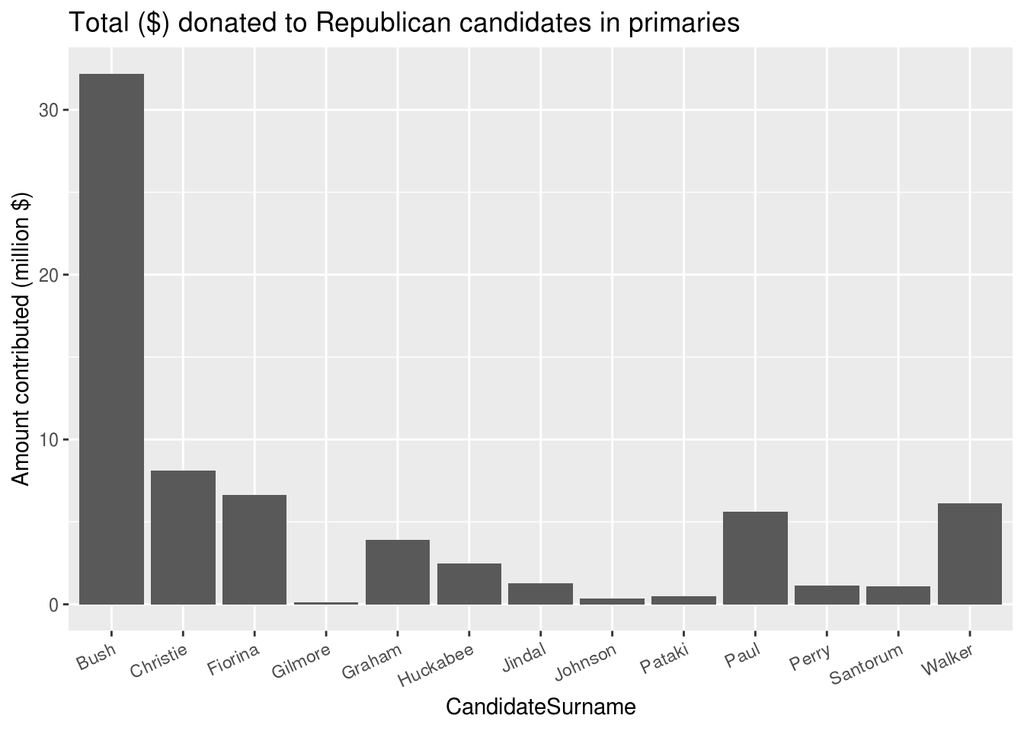

Looking at the other Republican candidates, it is noticeable how much less money they attracted in comparison to the two main Democratic party candidates. Could it be that this is the result of the much larger number of candidates? I.e. is the same amount of funding shared out between a larger number of candidates?

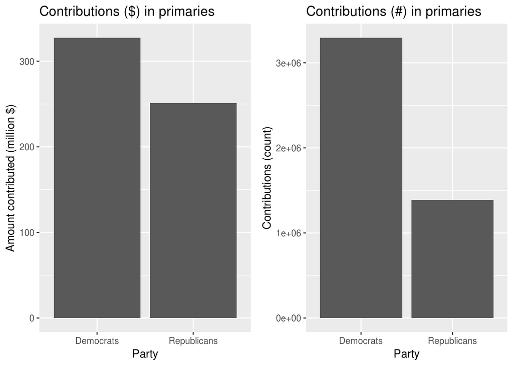

The total amount of contributions received by Republican party candidates was somewhat smaller - perhaps 1/5 - and shared between 17 different candidates. There are also less than half the number of contribution to the Republican candidates in the primaries.

Now to continue with the analysis of the final 5 Repulican candidates with a box plot.

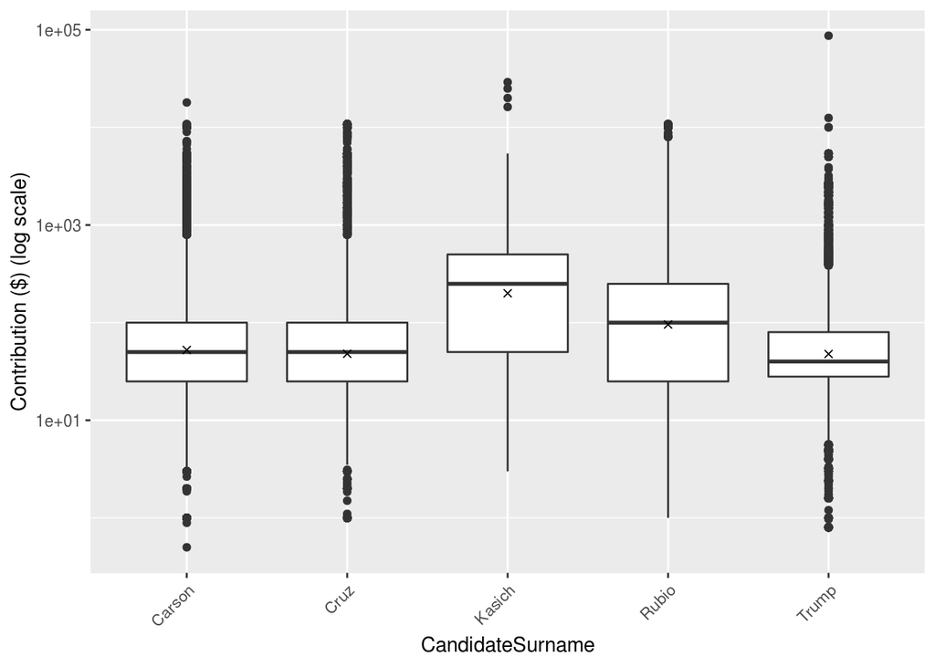

The median contributed amount was highest for the Kasich and Rubio campaigns. Trump received the lowest average (median) contributions of the final 5 candidates - but also the highest outliers.

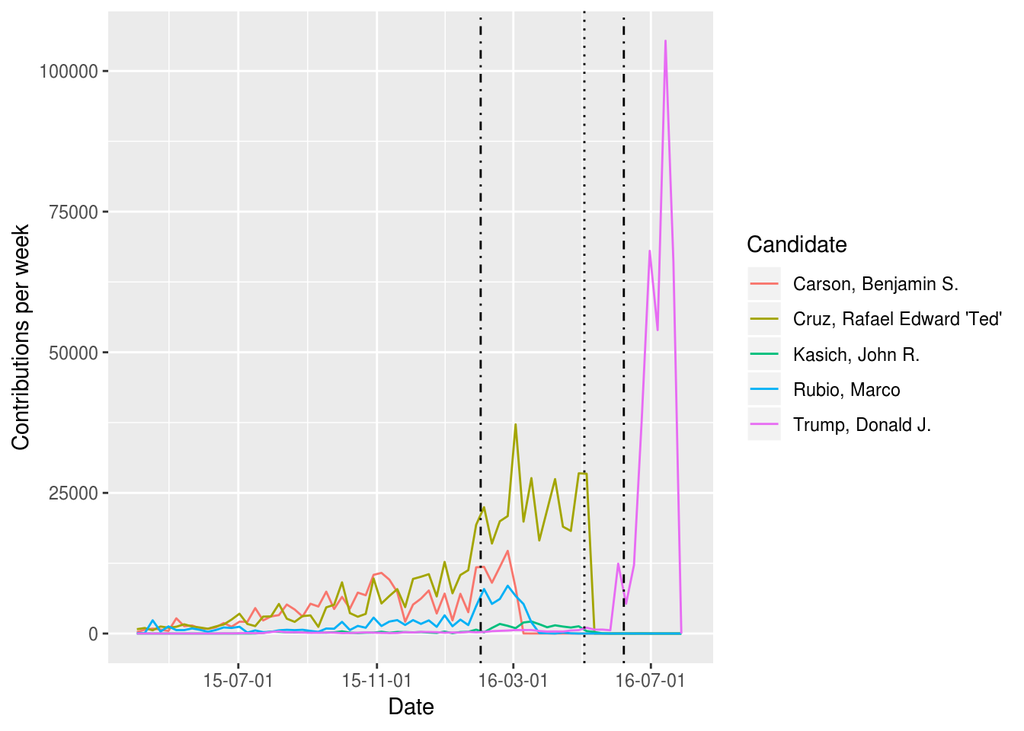

The start and the end of the primaries contests are shown by vertical lines. Cruz and Kasich suspended their campaigns after the Indiana primaries on 3.May (middle line), after which Trump remained as the sole candidate. Carson withdrew on 4.March, Rubio on 15. March.

(source: https://en.wikipedia.org/wiki/2016_Republican_Party_presidential_primaries)

Surprisingly perhaps, Trump received the vast majority of primary contributions after the end of the primaries. This is quite different from the other candidates who received the bulk of contributions during their primary campaign.

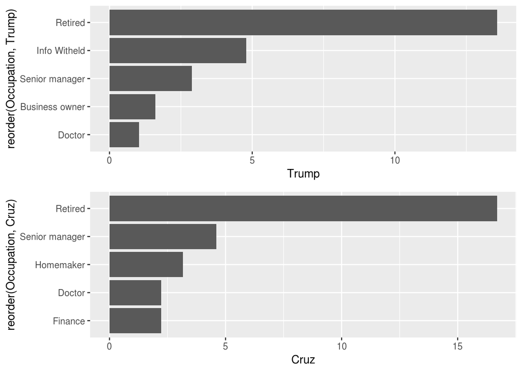

Compared to the Democrats, the two main Republican candidates have a more similar donor base.

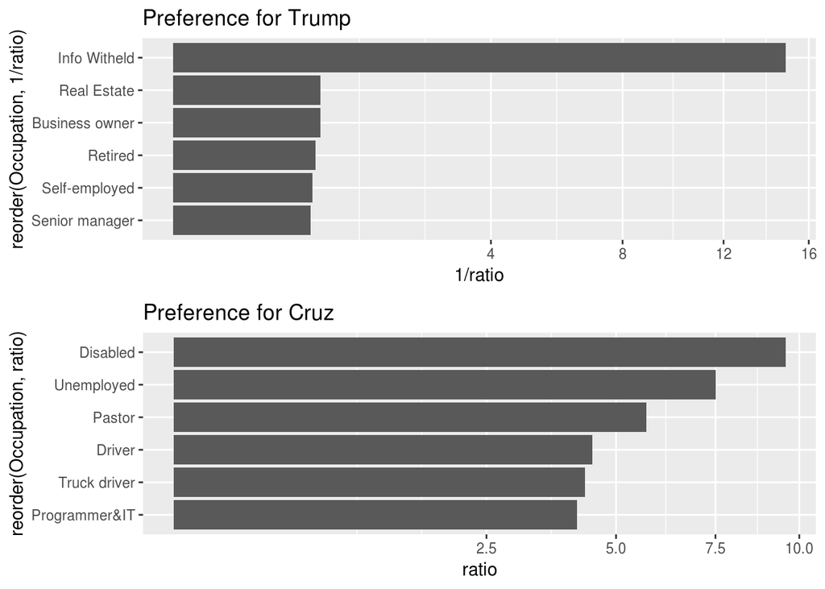

Again, compared to the Democrats, the preferences for either of the two top Republican candidates are less pronounced.